# Pima Indians Diabetes

Ammar Al-Hawashem

16/10/2021

## **Part1: Introduction**

## What is the project?

A population of women who were at least 21 years old, of Pima Indian heritage and living near Phoenix, Arizona, was tested for diabetes according to World Health Organization criteria. The data were collected by the US National Institute of Diabetes and Digestive and Kidney Diseases and published in 1988.

| Information | Description |
| --- | --- |
| Problem type | Supervised binary classification |
| Response variable | Diabetes positive or negative response (i.e. “pos,” “neg”) |
| Features | 8 |
| Observations | 768 |
| Objective | Use biological attributes to predict the presence of diabetes |

## What are the features and the target?

| Variable | Description |
| --- | --- |
| pregnant | Number of times pregnant |
| glucose | Plasma glucose concentration (glucose tolerance test) |
| pressure | Diastolic blood pressure (mm Hg) |
| triceps | Triceps skin fold thickness (mm) |
| insulin | 2-Hour serum insulin (mu U/ml) |
| mass | Body mass index (weight in kg/(height in m^2)) |
| pedigree | Diabetes pedigree function |
| age | Age (years) |
| diabetes | Class variable (test for diabetes) |

## **Part2: Set-up**

### Install used libraries

In addition to the necessary libraries (tidyverse & tidymodel)m you may want to install the below libraries:

```r
install.packages("corrplot") #for visualization
install.packages("themis")   #for step_smote()  --> up-sampling
install.packages("ranger")   #for random forest model
```

### Load the necessary libraries

```r
library(tidyverse)
library(tidymodels)
library(visdat)
library(naniar)
library(GGally)
```

```r
library(corrplot)
library(themis)
library(ranger)
library(knitr)
```

### Set-up

Let’s Load the dataset to our environment:

```r
pima <- readr::read_csv("data/pima.csv")
pima
```

```
## # A tibble: 768 x 9
##    pregnant glucose pressure triceps insulin  mass pedigree   age diabetes
##       <dbl>   <dbl>    <dbl>   <dbl>   <dbl> <dbl>    <dbl> <dbl> <chr>
##  1        6     148       72      35       0  33.6    0.627    50 pos
##  2        1      85       66      29       0  26.6    0.351    31 neg
##  3        8     183       64       0       0  23.3    0.672    32 pos
##  4        1      89       66      23      94  28.1    0.167    21 neg
##  5        0     137       40      35     168  43.1    2.29     33 pos
##  6        5     116       74       0       0  25.6    0.201    30 neg
##  7        3      78       50      32      88  31      0.248    26 pos
##  8       10     115        0       0       0  35.3    0.134    29 neg
##  9        2     197       70      45     543  30.5    0.158    53 pos
## 10        8     125       96       0       0   0      0.232    54 pos
## # ... with 758 more rows
```

## **Part3: Pre-work**

I Always like to use skimr::skim() to give me great view of the data: Table: Data summary

| Name | pima |
| --- | --- |
| Number of rows | 768 |
| Number of columns | 9 |
| _______________________ |  |
| Column type frequency: |  |
| character | 1 |
| numeric | 8 |
| ________________________ |  |
| Group variables | None |

**Variable type: character**

| skim_variable | n_missing | complete_rate | min | max | empty | n_unique | whitespace |
| --- | --- | --- | --- | --- | --- | --- | --- |
| diabetes | 0 | 1 | 3 | 3 | 0 | 2 | 0 |

**Variable type: numeric**

| skim_variable | n_missing | complete_rate | mean | sd | p0 | p25 | p50 | p75 | p100 | hist |
| --- | --- | --- | --- | --- | --- | --- | --- | --- | --- | --- |
| pregnant | 0 | 1 | 3.85 | 3.37 | 0.00 | 1.00 | 3.00 | 6.00 | 17.00 | ▇▃▂▁▁ |
| glucose | 0 | 1 | 120.89 | 31.97 | 0.00 | 99.00 | 117.00 | 140.25 | 199.00 | ▁▁▇▆▂ |
| pressure | 0 | 1 | 69.11 | 19.36 | 0.00 | 62.00 | 72.00 | 80.00 | 122.00 | ▁▁▇▇▁ |
| triceps | 0 | 1 | 20.54 | 15.95 | 0.00 | 0.00 | 23.00 | 32.00 | 99.00 | ▇▇▂▁▁ |
| insulin | 0 | 1 | 79.80 | 115.24 | 0.00 | 0.00 | 30.50 | 127.25 | 846.00 | ▇▁▁▁▁ |
| mass | 0 | 1 | 31.99 | 7.88 | 0.00 | 27.30 | 32.00 | 36.60 | 67.10 | ▁▃▇▂▁ |
| pedigree | 0 | 1 | 0.47 | 0.33 | 0.08 | 0.24 | 0.37 | 0.63 | 2.42 | ▇▃▁▁▁ |
| age | 0 | 1 | 33.24 | 11.76 | 21.00 | 24.00 | 29.00 | 41.00 | 81.00 | ▇▃▁▁▁ |

## **Part4: Exercises**

###1- Assess the distribution of the target / response variable.

#### A- Is the response skewed?

Before we answer, we should convert it is type from character into factor:

```r
pima$diabetes = as.factor(pima$diabetes)
```

Now let’s check its distribuation:

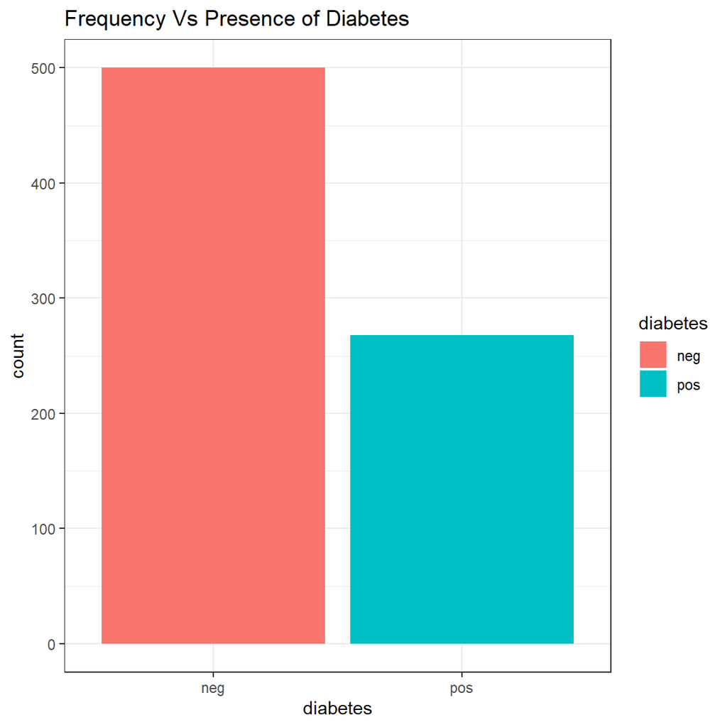

```r
ggplot(pima, aes(x=diabetes, fill= diabetes)) +
  geom_bar() +
  labs(title = "Frequency Vs Presence of Diabetes") +
  theme_bw()
```

```r
sum(pima$diabetes == "neg")/sum(pima$diabetes == "pos")
```

```
## [1] 1.865672
```

It can be notuced that the number of negative cases are almost double the positive once (which is expected). Therfore, we have a skewed target

#### B- Does applying a transformation normalize the distribution?

Since we have imbalance data with relatively small number of observation (<800). I’ll do up-sampling for the positive cases.

### 2- Assess the dataset for missingness.

#### A- How many observations have missing values?

Data summary

| Name | pima |
| --- | --- |
| Number of rows | 768 |
| Number of columns | 9 |
| _______________________ |  |
| Column type frequency: |  |
| factor | 1 |
| numeric | 8 |
| ________________________ |  |
| Group variables | None |

**Variable type: factor**

| skim_variable | n_missing | complete_rate | ordered | n_unique | top_counts |
| --- | --- | --- | --- | --- | --- |
| diabetes | 0 | 1 | FALSE | 2 | neg: 500, pos: 268 |

**Variable type: numeric**

| skim_variable | n_missing | complete_rate | mean | sd | p0 | p25 | p50 | p75 | p100 | hist |
| --- | --- | --- | --- | --- | --- | --- | --- | --- | --- | --- |
| pregnant | 0 | 1 | 3.85 | 3.37 | 0.00 | 1.00 | 3.00 | 6.00 | 17.00 | ▇▃▂▁▁ |
| glucose | 0 | 1 | 120.89 | 31.97 | 0.00 | 99.00 | 117.00 | 140.25 | 199.00 | ▁▁▇▆▂ |
| pressure | 0 | 1 | 69.11 | 19.36 | 0.00 | 62.00 | 72.00 | 80.00 | 122.00 | ▁▁▇▇▁ |
| triceps | 0 | 1 | 20.54 | 15.95 | 0.00 | 0.00 | 23.00 | 32.00 | 99.00 | ▇▇▂▁▁ |
| insulin | 0 | 1 | 79.80 | 115.24 | 0.00 | 0.00 | 30.50 | 127.25 | 846.00 | ▇▁▁▁▁ |
| mass | 0 | 1 | 31.99 | 7.88 | 0.00 | 27.30 | 32.00 | 36.60 | 67.10 | ▁▃▇▂▁ |
| pedigree | 0 | 1 | 0.47 | 0.33 | 0.08 | 0.24 | 0.37 | 0.63 | 2.42 | ▇▃▁▁▁ |
| age | 0 | 1 | 33.24 | 11.76 | 21.00 | 24.00 | 29.00 | 41.00 | 81.00 | ▇▃▁▁▁ |

As part 3, you can notice that fortunately there are no missing values. However, 6 out of the 8 features have zero values.

The question is: are these zeros are informative or missingness at random? The answer is: It is informative just in the “pregnant column” and the rest are considered as missingness at random. Therefore, let’s convert these zeros into ‘na’

a- Let’s excu;de the feature with the informative zero

```r
pima %>%
  select(-pregnant)  -> pima_na
pima_na
```

```
## # A tibble: 768 x 8
##    glucose pressure triceps insulin  mass pedigree   age diabetes
##      <dbl>    <dbl>   <dbl>   <dbl> <dbl>    <dbl> <dbl> <fct>
##  1     148       72      35       0  33.6    0.627    50 pos
##  2      85       66      29       0  26.6    0.351    31 neg
##  3     183       64       0       0  23.3    0.672    32 pos
##  4      89       66      23      94  28.1    0.167    21 neg
##  5     137       40      35     168  43.1    2.29     33 pos
##  6     116       74       0       0  25.6    0.201    30 neg
##  7      78       50      32      88  31      0.248    26 pos
##  8     115        0       0       0  35.3    0.134    29 neg
##  9     197       70      45     543  30.5    0.158    53 pos
## 10     125       96       0       0   0      0.232    54 pos
## # ... with 758 more rows
```

b- Let’s convert the zeros into NA’s

```r
  replace_with_na_all(data = pima_na, condition = ~.  ==0) ->pima_na
pima_na
```

```
## # A tibble: 768 x 8
##    glucose pressure triceps insulin  mass pedigree   age diabetes
##      <dbl>    <dbl>   <dbl>   <dbl> <dbl>    <dbl> <dbl> <fct>
##  1     148       72      35      NA  33.6    0.627    50 pos
##  2      85       66      29      NA  26.6    0.351    31 neg
##  3     183       64      NA      NA  23.3    0.672    32 pos
##  4      89       66      23      94  28.1    0.167    21 neg
##  5     137       40      35     168  43.1    2.29     33 pos
##  6     116       74      NA      NA  25.6    0.201    30 neg
##  7      78       50      32      88  31      0.248    26 pos
##  8     115       NA      NA      NA  35.3    0.134    29 neg
##  9     197       70      45     543  30.5    0.158    53 pos
## 10     125       96      NA      NA  NA      0.232    54 pos
## # ... with 758 more rows
```

c- Let’s mutate the pregnant feature

```r
pima_na %>%
  mutate(pregnant = pima$pregnant) -> pima_na
pima_na
```

```
## # A tibble: 768 x 9
##    glucose pressure triceps insulin  mass pedigree   age diabetes pregnant
##      <dbl>    <dbl>   <dbl>   <dbl> <dbl>    <dbl> <dbl> <fct>       <dbl>
##  1     148       72      35      NA  33.6    0.627    50 pos             6
##  2      85       66      29      NA  26.6    0.351    31 neg             1
##  3     183       64      NA      NA  23.3    0.672    32 pos             8
##  4      89       66      23      94  28.1    0.167    21 neg             1
##  5     137       40      35     168  43.1    2.29     33 pos             0
##  6     116       74      NA      NA  25.6    0.201    30 neg             5
##  7      78       50      32      88  31      0.248    26 pos             3
##  8     115       NA      NA      NA  35.3    0.134    29 neg            10
##  9     197       70      45     543  30.5    0.158    53 pos             2
## 10     125       96      NA      NA  NA      0.232    54 pos             8
## # ... with 758 more rows
```

Let’s go back to the question #### B- How many observations have missing values?

```r
skimr::skim(pima_na)
```

Data summary

| Name | pima_na |
| --- | --- |
| Number of rows | 768 |
| Number of columns | 9 |
| _______________________ |  |
| Column type frequency: |  |
| factor | 1 |
| numeric | 8 |
| ________________________ |  |
| Group variables | None |

**Variable type: factor**

| skim_variable | n_missing | complete_rate | ordered | n_unique | top_counts |
| --- | --- | --- | --- | --- | --- |
| diabetes | 0 | 1 | FALSE | 2 | neg: 500, pos: 268 |

**Variable type: numeric**

| skim_variable | n_missing | complete_rate | mean | sd | p0 | p25 | p50 | p75 | p100 | hist |
| --- | --- | --- | --- | --- | --- | --- | --- | --- | --- | --- |
| glucose | 5 | 0.99 | 121.69 | 30.54 | 44.00 | 99.00 | 117.00 | 141.00 | 199.00 | ▁▇▇▃▂ |
| pressure | 35 | 0.95 | 72.41 | 12.38 | 24.00 | 64.00 | 72.00 | 80.00 | 122.00 | ▁▃▇▂▁ |
| triceps | 227 | 0.70 | 29.15 | 10.48 | 7.00 | 22.00 | 29.00 | 36.00 | 99.00 | ▆▇▁▁▁ |
| insulin | 374 | 0.51 | 155.55 | 118.78 | 14.00 | 76.25 | 125.00 | 190.00 | 846.00 | ▇▂▁▁▁ |
| mass | 11 | 0.99 | 32.46 | 6.92 | 18.20 | 27.50 | 32.30 | 36.60 | 67.10 | ▅▇▃▁▁ |
| pedigree | 0 | 1.00 | 0.47 | 0.33 | 0.08 | 0.24 | 0.37 | 0.63 | 2.42 | ▇▃▁▁▁ |
| age | 0 | 1.00 | 33.24 | 11.76 | 21.00 | 24.00 | 29.00 | 41.00 | 81.00 | ▇▃▁▁▁ |
| pregnant | 0 | 1.00 | 3.85 | 3.37 | 0.00 | 1.00 | 3.00 | 6.00 | 17.00 | ▇▃▂▁▁ |

As you can see, we are able to define the number of missingness at random for each feature.

#### B- Plot the missing values. Does there appear to be any patterns to the missing values?

Here is a great way to check the quality of the observations that have a missing value

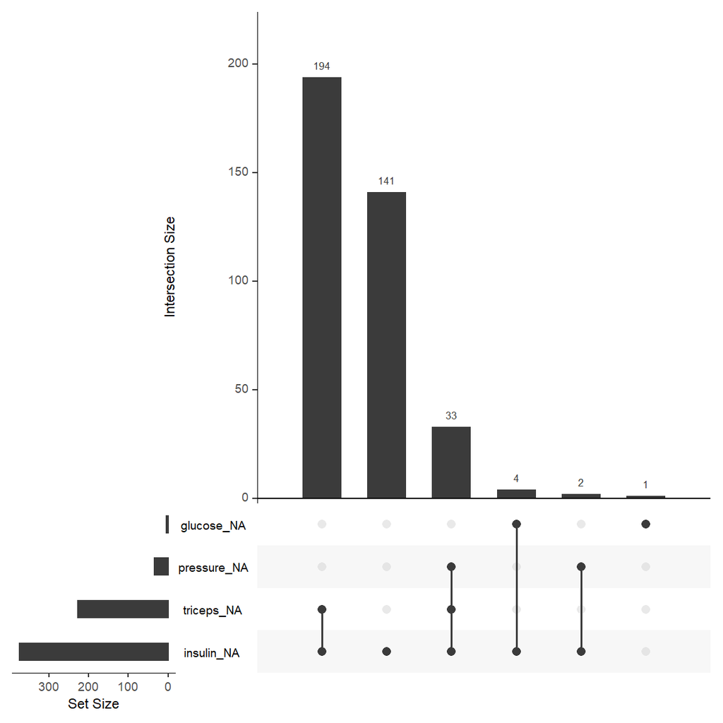

```r
pima_na %>%
  select(glucose, pressure, triceps, , insulin, , pedigree) %>%
  gg_miss_upset()
```

As you can see, just 33 observations have 3 missings features . Due to the small number of observation we will keep them. Also, the insulin is missed in almost half of the data

#### C- How do you think the different imputation approaches would impact modeling results?

They will improve it. However, there is no uniform procedure for the imputation that can be applied for all cases

### 3- Assess the variance across the features.

#### A- Do any features have zero variance?

From the data summary skimr::skim(), we didn’t have any feature with standard deviation = 0, As a result, no variance as well since squired root of zero is zero #### B- Do any features have near-zero variance? Let’s check for “pedigree” since it has a small sd:

```r
pima_na %>%
  summarise(variance_pedigree = var(pedigree))
```

```
## # A tibble: 1 x 1
##   variance_pedigree
##               <dbl>
## 1             0.110
```

### 4- Assess the numeric features.

There are two great visualization that can be used. However, we need to omit the NA values firstly

```r
na.omit(pima_na) ->pima_NoNa
pima_NoNa
```

```
## # A tibble: 392 x 9
##    glucose pressure triceps insulin  mass pedigree   age diabetes pregnant
##      <dbl>    <dbl>   <dbl>   <dbl> <dbl>    <dbl> <dbl> <fct>       <dbl>
##  1      89       66      23      94  28.1    0.167    21 neg             1
##  2     137       40      35     168  43.1    2.29     33 pos             0
##  3      78       50      32      88  31      0.248    26 pos             3
##  4     197       70      45     543  30.5    0.158    53 pos             2
##  5     189       60      23     846  30.1    0.398    59 pos             1
##  6     166       72      19     175  25.8    0.587    51 pos             5
##  7     118       84      47     230  45.8    0.551    31 pos             0
##  8     103       30      38      83  43.3    0.183    33 neg             1
##  9     115       70      30      96  34.6    0.529    32 pos             1
## 10     126       88      41     235  39.3    0.704    27 neg             3
## # ... with 382 more rows
```

The first useful visualization

```r
  ggscatmat(data = pima_NoNa, , color = "diabetes", alpha = 0.7)
```

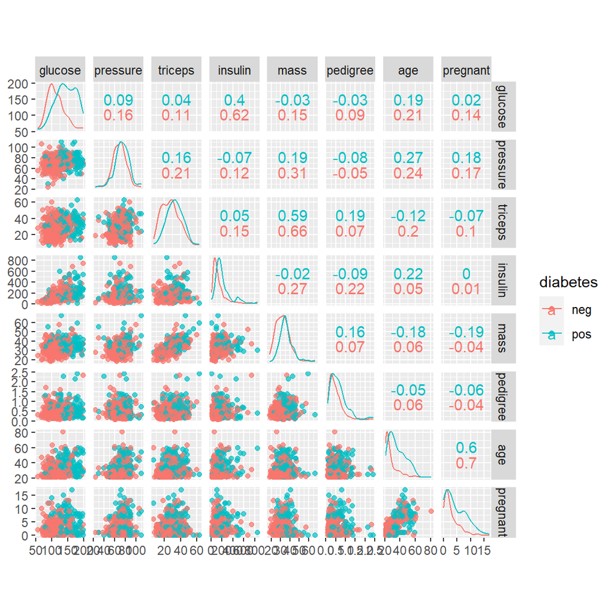

The second plot is a Correlation matrix plot

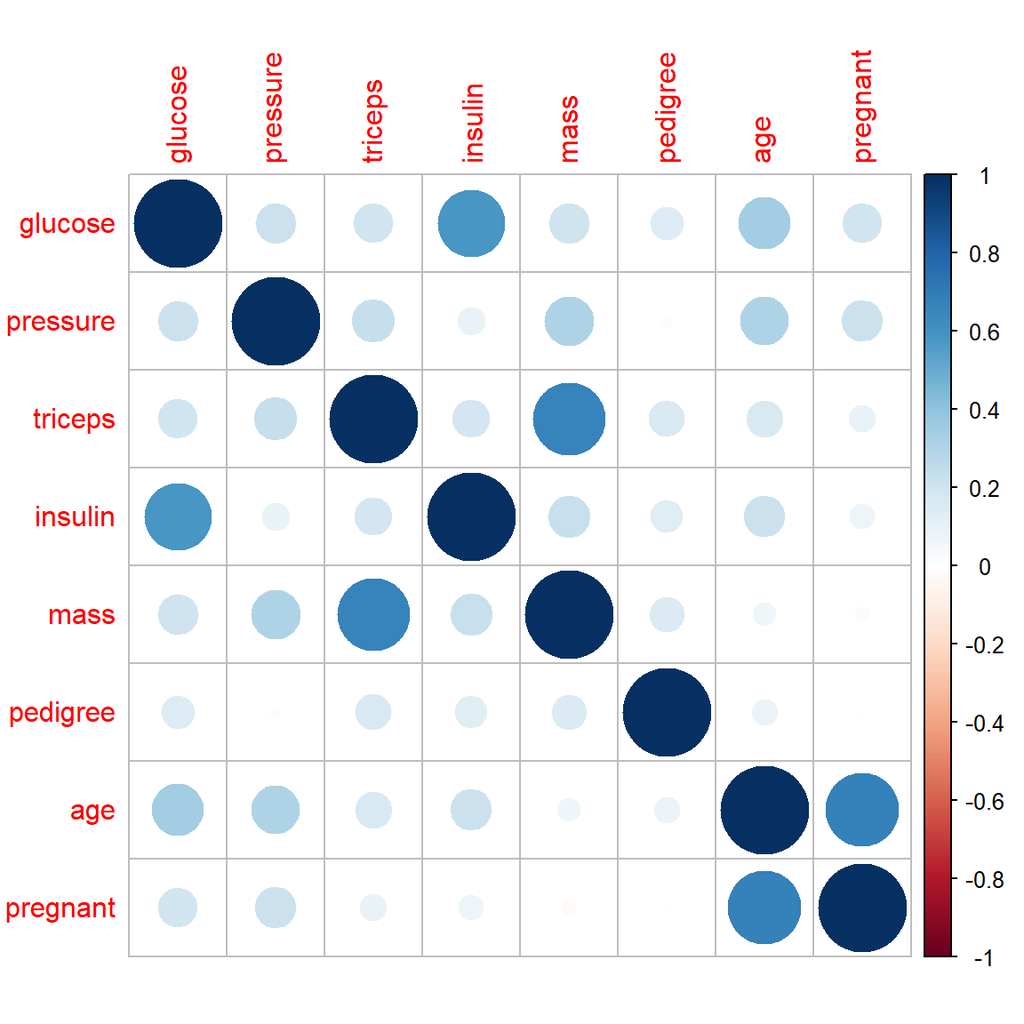

```r
 select(pima_NoNa, -diabetes) -> correlationM
corr = cor(correlationM)
 corrplot(corr)
```

You can notice that pregnant & age have a high correlation value whcih is expected

#### A- Do some features have significant skewness?

They all have except the pressure feature

#### B- Do features have a wide range of values that would benefit from standardization?

```r
skimr::skim(pima_na)
```

Data summary

| Name | pima_na |
| --- | --- |
| Number of rows | 768 |
| Number of columns | 9 |
| _______________________ |  |
| Column type frequency: |  |
| factor | 1 |
| numeric | 8 |
| ________________________ |  |
| Group variables | None |

**Variable type: factor**

| skim_variable | n_missing | complete_rate | ordered | n_unique | top_counts |
| --- | --- | --- | --- | --- | --- |
| diabetes | 0 | 1 | FALSE | 2 | neg: 500, pos: 268 |

**Variable type: numeric**

| skim_variable | n_missing | complete_rate | mean | sd | p0 | p25 | p50 | p75 | p100 | hist |
| --- | --- | --- | --- | --- | --- | --- | --- | --- | --- | --- |
| glucose | 5 | 0.99 | 121.69 | 30.54 | 44.00 | 99.00 | 117.00 | 141.00 | 199.00 | ▁▇▇▃▂ |
| pressure | 35 | 0.95 | 72.41 | 12.38 | 24.00 | 64.00 | 72.00 | 80.00 | 122.00 | ▁▃▇▂▁ |
| triceps | 227 | 0.70 | 29.15 | 10.48 | 7.00 | 22.00 | 29.00 | 36.00 | 99.00 | ▆▇▁▁▁ |
| insulin | 374 | 0.51 | 155.55 | 118.78 | 14.00 | 76.25 | 125.00 | 190.00 | 846.00 | ▇▂▁▁▁ |
| mass | 11 | 0.99 | 32.46 | 6.92 | 18.20 | 27.50 | 32.30 | 36.60 | 67.10 | ▅▇▃▁▁ |
| pedigree | 0 | 1.00 | 0.47 | 0.33 | 0.08 | 0.24 | 0.37 | 0.63 | 2.42 | ▇▃▁▁▁ |
| age | 0 | 1.00 | 33.24 | 11.76 | 21.00 | 24.00 | 29.00 | 41.00 | 81.00 | ▇▃▁▁▁ |
| pregnant | 0 | 1.00 | 3.85 | 3.37 | 0.00 | 1.00 | 3.00 | 6.00 | 17.00 | ▇▃▂▁▁ |

There are a wide range, so normliazation sounds useful

### 5- Assess the categorical features.

We don’t have any

### 6- Execute a basic feature engineering process.

#### A-apply a KNN model to your data without pre-applying feature engineering processes.

Let’s split our data into training and testing sets: I’ll use stratified sampling to preserve the distribution since we have almost double negative cases

```r
set.seed(1234)
initial_split(data = pima_NoNa, strata = diabetes) -> pima_NoNa_split
training(pima_NoNa_split) -> pima_NoNa_train
testing(pima_NoNa_split) -> pima_NoNa_test
```

We are going to use resampling to evaluate model performance, so let’s get those resample sets ready.

```r
set.seed(1234)
pima_folds <- vfold_cv(pima_NoNa_train, strata = diabetes, repeats = 5)
pima_folds
```

```
## #  10-fold cross-validation repeated 5 times using stratification
## # A tibble: 50 x 3
##    splits           id      id2
##    <list>           <chr>   <chr>
##  1 <split [263/30]> Repeat1 Fold01
##  2 <split [263/30]> Repeat1 Fold02
##  3 <split [263/30]> Repeat1 Fold03
##  4 <split [263/30]> Repeat1 Fold04
##  5 <split [263/30]> Repeat1 Fold05
##  6 <split [263/30]> Repeat1 Fold06
##  7 <split [264/29]> Repeat1 Fold07
##  8 <split [265/28]> Repeat1 Fold08
##  9 <split [265/28]> Repeat1 Fold09
## 10 <split [265/28]> Repeat1 Fold10
## # ... with 40 more rows
```

FROM HERE

Build models without a recipe:

Specify the model

```r
pima_rec_before <- recipe(diabetes~ ., data= pima_NoNa_train)
```

Then fit it

```r
pima_rec_before %>%
  prep()
```

```
## Recipe
##
## Inputs:
##
##       role #variables
##    outcome          1
##  predictor          8
##
## Training data contained 293 data points and no missing data.
```

```r
knn_spec_before <- nearest_neighbor() %>%
  set_engine("kknn") %>%
  set_mode("classification")
```

Add the recipe and the model to the workshop

```r
pima_wf <- workflow() %>%
  add_recipe(pima_rec_before) %>%
  add_model(knn_spec_before)
pima_wf
```

```
## == Workflow ====================================================================
## Preprocessor: Recipe
## Model: nearest_neighbor()
##
## -- Preprocessor ----------------------------------------------------------------
## 0 Recipe Steps
##
## -- Model -----------------------------------------------------------------------
## K-Nearest Neighbor Model Specification (classification)
##
## Computational engine: kknn
```

```r
pima_wf %>%
  fit_resamples(
    resamples = pima_folds,
    metrics = metric_set( roc_auc, accuracy, sensitivity, specificity),
    control = control_resamples(save_pred = TRUE) #so they can be used in plotting
  ) -> knn_rs_before
```

Evaluate models

```r
collect_metrics(knn_rs_before)
```

```
## # A tibble: 4 x 6
##   .metric  .estimator  mean     n std_err .config
##   <chr>    <chr>      <dbl> <int>   <dbl> <chr>
## 1 accuracy binary     0.778    50  0.0111 Preprocessor1_Model1
## 2 roc_auc  binary     0.809    50  0.0148 Preprocessor1_Model1
## 3 sens     binary     0.877    50  0.0109 Preprocessor1_Model1
## 4 spec     binary     0.578    50  0.0202 Preprocessor1_Model1
```

```r
knn_rs_before %>%
  conf_mat_resampled()
```

```
## # A tibble: 4 x 3
##   Prediction Truth  Freq
##   <fct>      <fct> <dbl>
## 1 neg        neg   172.
## 2 neg        pos    41.2
## 3 pos        neg    24.2
## 4 pos        pos    55.8
```

Let’s fit one more time to the training data and evaluate on the testing data using the function last_fit().

```r
pima_final_before <- pima_wf %>%
  last_fit(pima_NoNa_split,
           metrics = metric_set( roc_auc, accuracy, sensitivity, specificity),
  )
```

The metrics and predictions here are on the testing data:

```r
collect_metrics(pima_final_before)
```

```
## # A tibble: 4 x 4
##   .metric  .estimator .estimate .config
##   <chr>    <chr>          <dbl> <chr>
## 1 accuracy binary         0.717 Preprocessor1_Model1
## 2 sens     binary         0.879 Preprocessor1_Model1
## 3 spec     binary         0.394 Preprocessor1_Model1
## 4 roc_auc  binary         0.753 Preprocessor1_Model1
```

NOTE: we use here the data with the NA’s

```r
set.seed(1234)
initial_split(data = pima_na, strata = diabetes) -> pima_split
training(pima_split) -> pima_train
testing(pima_split) -> pima_test
```

```r
set.seed(1234)
pima_folds_after <- vfold_cv(pima_train, strata = diabetes, repeats = 5)
pima_folds_after
```

```
## #  10-fold cross-validation repeated 5 times using stratification
## # A tibble: 50 x 3
##    splits           id      id2
##    <list>           <chr>   <chr>
##  1 <split [517/59]> Repeat1 Fold01
##  2 <split [518/58]> Repeat1 Fold02
##  3 <split [518/58]> Repeat1 Fold03
##  4 <split [518/58]> Repeat1 Fold04
##  5 <split [518/58]> Repeat1 Fold05
##  6 <split [519/57]> Repeat1 Fold06
##  7 <split [519/57]> Repeat1 Fold07
##  8 <split [519/57]> Repeat1 Fold08
##  9 <split [519/57]> Repeat1 Fold09
## 10 <split [519/57]> Repeat1 Fold10
## # ... with 40 more rows
```

Prepare the recipe with the feature engineering

```r
pima_rec_after <- recipe(diabetes~ ., data= pima_train) %>%
  step_zv(all_numeric()) %>%
  step_nzv(all_numeric()) %>%
  step_impute_mean(glucose) %>%
  step_impute_mean(pressure) %>%
  step_impute_knn(all_predictors()) %>%
  step_normalize(all_numeric()) %>%
  step_smote(diabetes)
```

The same specification

```r
knn_spec_before <- nearest_neighbor() %>%
  set_engine("kknn") %>%
  set_mode("classification")
```

Add the recipe to the workshop

```r
pima_wf <- workflow() %>%
  add_recipe(pima_rec_after) %>%
  add_model(knn_spec_before)
pima_wf
```

```
## == Workflow ====================================================================
## Preprocessor: Recipe
## Model: nearest_neighbor()
##
## -- Preprocessor ----------------------------------------------------------------
## 7 Recipe Steps
##
## * step_zv()
## * step_nzv()
## * step_impute_mean()
## * step_impute_mean()
## * step_impute_knn()
## * step_normalize()
## * step_smote()
##
## -- Model -----------------------------------------------------------------------
## K-Nearest Neighbor Model Specification (classification)
##
## Computational engine: kknn
```

```r
pima_wf %>%
  fit_resamples(
    resamples = pima_folds_after,
    metrics = metric_set( roc_auc, accuracy, sensitivity, specificity),
    control = control_resamples(save_pred = TRUE) #so they can be used in plotting
  ) -> knn_rs_after
```

```r
collect_metrics(knn_rs_after)
```

```
## # A tibble: 4 x 6
##   .metric  .estimator  mean     n std_err .config
##   <chr>    <chr>      <dbl> <int>   <dbl> <chr>
## 1 accuracy binary     0.697    50 0.00704 Preprocessor1_Model1
## 2 roc_auc  binary     0.755    50 0.00765 Preprocessor1_Model1
## 3 sens     binary     0.704    50 0.00950 Preprocessor1_Model1
## 4 spec     binary     0.685    50 0.0121  Preprocessor1_Model1
```

```r
knn_rs_before %>%
  conf_mat_resampled()
```

```
## # A tibble: 4 x 3
##   Prediction Truth  Freq
##   <fct>      <fct> <dbl>
## 1 neg        neg   172.
## 2 neg        pos    41.2
## 3 pos        neg    24.2
## 4 pos        pos    55.8
```

Let’s fit one more time to the training data and evaluate on the testing data using the function last_fit().

```r
pima_final_after <- pima_wf %>%
  last_fit(pima_split,
           metrics = metric_set( roc_auc, accuracy, sensitivity, specificity),
  )
```

The metrics and predictions here are on the testing data:

```r
collect_metrics(pima_final_after)
```

```
## # A tibble: 4 x 4
##   .metric  .estimator .estimate .config
##   <chr>    <chr>          <dbl> <chr>
## 1 accuracy binary         0.714 Preprocessor1_Model1
## 2 sens     binary         0.704 Preprocessor1_Model1
## 3 spec     binary         0.731 Preprocessor1_Model1
## 4 roc_auc  binary         0.799 Preprocessor1_Model1
```

```r
collect_predictions(pima_final_after)
```

```
## # A tibble: 192 x 7
##    id               .pred_neg .pred_pos  .row .pred_class diabetes .config
##    <chr>                <dbl>     <dbl> <int> <fct>       <fct>    <chr>
##  1 train/test split     1         0         2 neg         neg      Preprocessor~
##  2 train/test split     0.465     0.535    10 pos         pos      Preprocessor~
##  3 train/test split     1         0        11 neg         neg      Preprocessor~
##  4 train/test split     0         1        14 pos         pos      Preprocessor~
##  5 train/test split     0.728     0.272    15 neg         pos      Preprocessor~
##  6 train/test split     0.551     0.449    16 neg         pos      Preprocessor~
##  7 train/test split     0.754     0.246    19 neg         neg      Preprocessor~
##  8 train/test split     0.160     0.840    21 pos         neg      Preprocessor~
##  9 train/test split     0.754     0.246    22 neg         neg      Preprocessor~
## 10 train/test split     0         1        23 pos         pos      Preprocessor~
## # ... with 182 more rows
```

```r
collect_predictions(pima_final_after) %>%
  conf_mat(diabetes, .pred_class)
```

```
##           Truth
## Prediction neg pos
##        neg  88  18
##        pos  37  49
```